# Matplotlib

# Introduction:

Matplotlib is one of the most popular Python packages used for data visualization. Matplotlib was originally written by John D. Hunter in 2003. Pyplot is a Matplotlib module which provides a MATLAB-like interface. Matplotlib is designed to be as usable as MATLAB, with the ability to use Python, and the advantage of being free and open-source. Matplotlib is open source and we can use it freely. The purpose of a plotting package is to assist you in visualizing your data as easily as possible, with all the necessary control that is, by using relatively high-level commands most of the time, and still have the ability to use the low-level commands when needed.

# Installation of Matplotlib:

If you have Python and PIP already installed on a system, then installation of Matplotlib is very easy. Install it using this command:

`pip install matplotlib`

Matplotlib requires the following dependencies:

- NumPy
- setuptools
- cycler
- dateutil
- kiwisolver
- Pillow
- pyparsing

# Anaconda distribution:

Anaconda is a free and open source distribution of the Python and R programming languages for large-scale data processing, predictive analytics, and scientific computing. The distribution makes package management and deployment simple and easy. Matplotlib and lots of other useful (data) science tools form part of the distribution. Package versions are managed by the package management system Conda. The advantage of Anaconda is that you have access to over 720 packages that can easily be installed with Anaconda's Conda, a package, dependency, and environment manager.

# Checking Matplotlib Version:

Once Matplotlib is installed, import it in your applications by adding the import module statement:

```python
import matplotlib
matplotlib.__version__
```

```
'3.1.3'
```

Most of the Matplotlib utilities lies under the pyplot submodule, and are usually imported under the plt alias:

```python
import matplotlib.pyplot as plt
```

matplotlib.pyplot is a collection of functions that make matplotlib work like MATLAB. Each pyplot function makes some change to a figure: e.g., creates a figure, creates a plotting area in a figure, plots some lines in a plotting area, decorates the plot with labels, etc.

# Generating visualizations with pyplot is very quick:

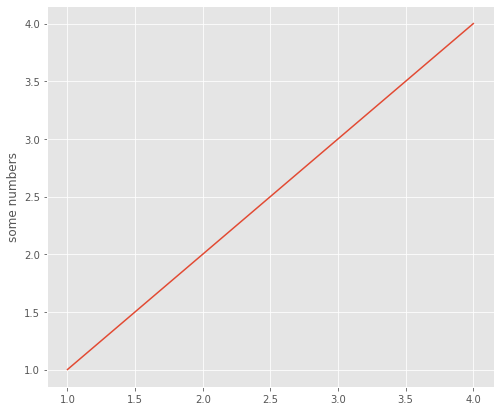

```python
import matplotlib.pyplot as plt
plt.plot([1, 2, 3, 4],[1, 2, 3, 4])
plt.ylabel('some numbers')
plt.show()
```

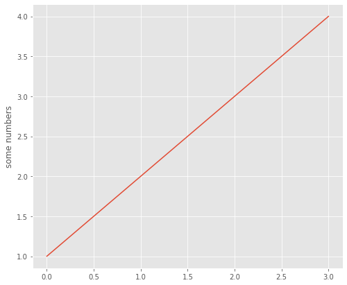

```python
plt.plot([1, 2, 3, 4])
plt.ylabel('some numbers')
plt.show()
```

You may be wondering why the x-axis ranges from 0-3 and the y-axis from 1-4. If you provide a single list or array to plot, matplotlib assumes it is a sequence of y values, and automatically generates the x values for you. Since python ranges start with 0, the default x vector has the same length as y but starts with 0. Hence the x data are [0, 1, 2, 3].

# Formatting the style of your plot:

For every x, y pair of arguments, there is an optional third argument which is the format string that indicates the color and line type of the plot. The letters and symbols of the format string are from MATLAB, and you concatenate a color string with a line style string. The default format string is 'b-', which is a solid blue line. For example, to plot the above with red circles, you would issue

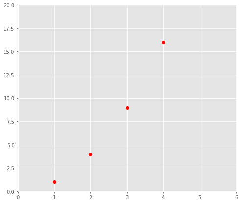

```python
plt.plot([1, 2, 3, 4], [1, 4, 9, 16], 'ro')
plt.axis([0, 6, 0, 20])
plt.show()
```

[figure not shown]

```python
plt.plot([1, 2, 3, 4], [1, 4, 9, 16], 'r+')     # ditto, but with red plusses
plt.axis([0, 6, 0, 20])
plt.show()
```

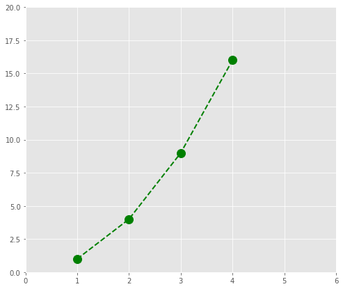

```python
plt.plot([1, 2, 3, 4], [1, 4, 9, 16],'go--', linewidth=2, markersize=12)
plt.axis([0, 6, 0, 20])
plt.show()
```

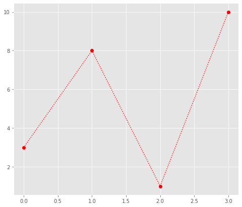

```python
ypoints = [3, 8, 1, 10]
plt.plot(ypoints, 'o:r')
plt.show()
```

Marker Size : You can use the keyword argument markersize or the shorter version, ms to set the size of the markers

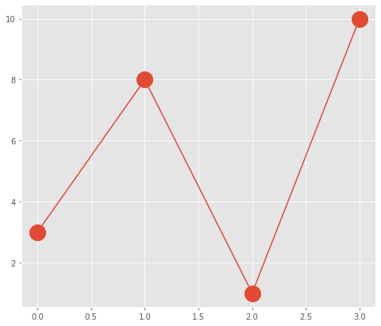

```python
ypoints = [3, 8, 1, 10]
plt.plot(ypoints, marker = 'o', ms = 20)
plt.show()
```

Marker Color: You can use the keyword argument markerfacecolor or the shorter mfc to set the color inside the edge of the markers:

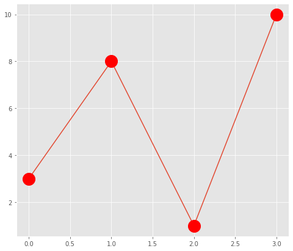

```python
ypoints =[3, 8, 1, 10]
plt.plot(ypoints, marker = 'o', ms = 20, mec = 'r', mfc = 'r')
plt.show()
```

For more visit

https://matplotlib.org/api/_as_gen/matplotlib.pyplot.plot.html#matplotlib.pyplot.plot

# Use with numpy

If matplotlib were limited to working with lists, it would be fairly useless for numeric processing. Generally, you will use numpy arrays. In fact, all sequences are converted to numpy arrays internally. The example below illustrates plotting several lines with different format styles in one function call using arrays.

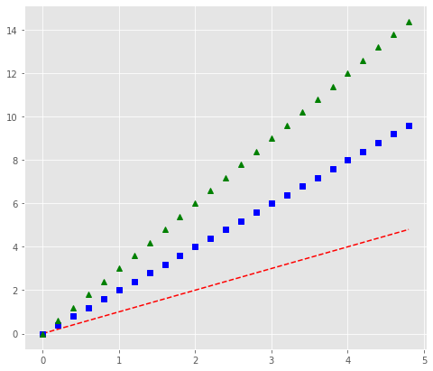

```python
import numpy as np
import matplotlib.pyplot as plt

# evenly sampled time at 200ms intervals
t = np.arange(0., 5., 0.2)

# red dashes, blue squares and green triangles
plt.plot(t, t, 'r--', t, t*2, 'bs', t, t*3, 'g^')
plt.show()
```

# Display Multiple Plots

the subplots() function takes three arguments that describes the layout of the figure. The layout is organized in rows and columns, which are represented by the first and second argument. The third argument represents the index of the current plot.

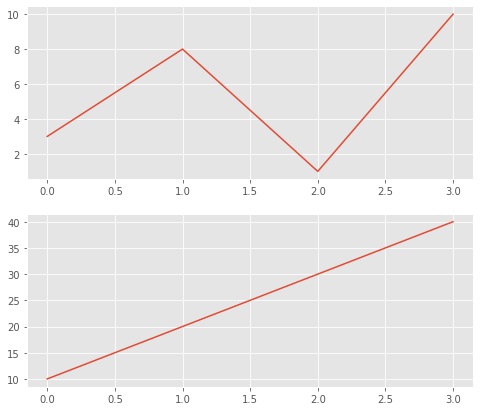

```python
x = np.array([0, 1, 2, 3])
y = np.array([3, 8, 1, 10])
plt.subplot(2, 1, 1)
plt.plot(x,y)
x = np.array([0, 1, 2, 3])
y = np.array([10, 20, 30, 40])
plt.subplot(2, 1, 2)
plt.plot(x,y)
plt.show()
```

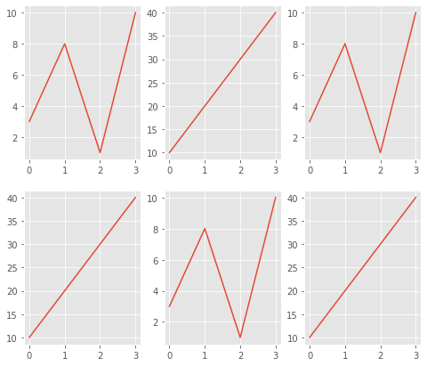

```python
x = np.array([0, 1, 2, 3])
y = np.array([3, 8, 1, 10])

plt.subplot(2, 3, 1)
plt.plot(x,y)

x = np.array([0, 1, 2, 3])
y = np.array([10, 20, 30, 40])

plt.subplot(2, 3, 2)
plt.plot(x,y)

x = np.array([0, 1, 2, 3])
y = np.array([3, 8, 1, 10])

plt.subplot(2, 3, 3)
plt.plot(x,y)

x = np.array([0, 1, 2, 3])
y = np.array([10, 20, 30, 40])

plt.subplot(2, 3, 4)
plt.plot(x,y)

x = np.array([0, 1, 2, 3])
y = np.array([3, 8, 1, 10])

plt.subplot(2, 3, 5)
plt.plot(x,y)

x = np.array([0, 1, 2, 3])
y = np.array([10, 20, 30, 40])

plt.subplot(2, 3, 6)
plt.plot(x,y)
plt.show()
```

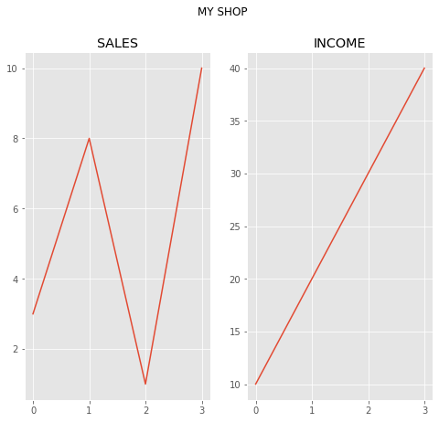

```python
x = np.array([0, 1, 2, 3])
y = np.array([3, 8, 1, 10])

plt.subplot(1, 2, 1)
plt.plot(x,y)
plt.title("SALES")

x = np.array([0, 1, 2, 3])
y = np.array([10, 20, 30, 40])

plt.subplot(1, 2, 2)
plt.plot(x,y)
plt.title("INCOME")

plt.suptitle("MY SHOP")
plt.show()
```

# Subplot2grid() Function

This function gives more flexibility in creating an axes object at a specific location of the grid. It also allows the axes object to be spanned across multiple rows or columns.

`Plt.subplot2grid(shape, location, rowspan, colspan)`

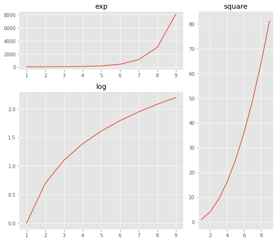

```python
a1 = plt.subplot2grid((3,3),(0,0),colspan = 2)
a2 = plt.subplot2grid((3,3),(0,2), rowspan = 3)
a3 = plt.subplot2grid((3,3),(1,0),rowspan = 2, colspan = 2)


x = np.arange(1,10)
a2.plot(x, x*x)
a2.set_title('square')
a1.plot(x, np.exp(x))
a1.set_title('exp')
a3.plot(x, np.log(x))
a3.set_title('log')
plt.tight_layout()
plt.show()
```

# Grids

The grid() function of axes object sets visibility of grid inside the figure to on or off. You can also display major / minor (or both) ticks of the grid. Additionally color, linestyle and linewidth properties can be set in the grid() function.

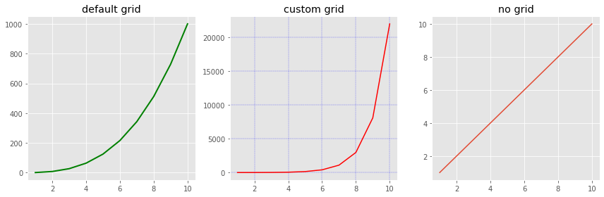

```python
import matplotlib.pyplot as plt
import numpy as np
fig, axes = plt.subplots(1,3, figsize = (12,4))
x = np.arange(1,11)
axes[0].plot(x, x**3, 'g',lw=2)
axes[0].grid(True)
axes[0].set_title('default grid')
axes[1].plot(x, np.exp(x), 'r')
axes[1].grid(color='b', ls = '-.', lw = 0.25)
axes[1].set_title('custom grid')
axes[2].plot(x,x)
axes[2].set_title('no grid')
fig.tight_layout()
plt.show()
```

# Working with text

text can be used to add text in an arbitrary location, and xlabel, ylabel and title are used to add text in the indicated locations (see Text in Matplotlib Plots for a more detailed example) Using mathematical expressions in text:

`plt.text(60, .025, r'$\mu=100,\ \sigma=15$')`

matplotlib accepts laTeX equation expressions in any text expression.

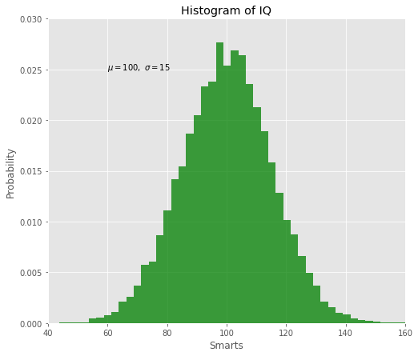

```python
mu, sigma = 100, 15
x = mu + sigma * np.random.randn(10000)

# the histogram of the data
n, bins, patches = plt.hist(x, 50, density=1, facecolor='g', alpha=0.75)


plt.xlabel('Smarts')
plt.ylabel('Probability')
plt.title('Histogram of IQ')
plt.text(60, .025, r'$\mu=100,\ \sigma=15$')
plt.axis([40, 160, 0, 0.03])
plt.grid(True)
plt.show()
```

# Annotating text

The uses of the basic text function above place text at an arbitrary position on the Axes. A common use for text is to annotate some feature of the plot, and the annotate method provides helper functionality to make annotations easy. In an annotation, there are two points to consider: the location being annotated represented by the argument xy and the location of the text xytext. Both of these arguments are (x, y) tuples.

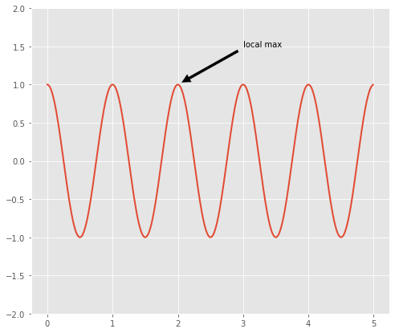

```python
ax = plt.subplot(111)
t = np.arange(0.0, 5.0, 0.01)
s = np.cos(2*np.pi*t)
line, = plt.plot(t, s, lw=2)

plt.annotate('local max', xy=(2, 1), xytext=(3, 1.5),
             arrowprops=dict(facecolor='black', shrink=0.05),
             )

plt.ylim(-2, 2)
plt.show()
```

# Logarithmic and other nonlinear axes

matplotlib.pyplot supports not only linear axis scales, but also logarithmic and logit scales. This is commonly used if data spans many orders of magnitude. Changing the scale of an axis is easy:

`plt.xscale('log')`

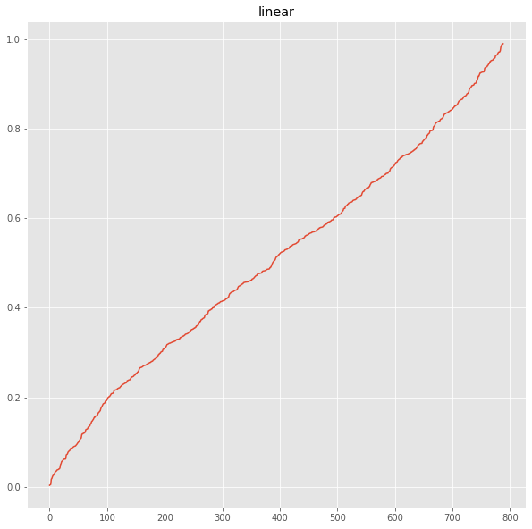

```python
from matplotlib.pyplot import figure

# make up some data in the open interval (0, 1)
y = np.random.normal(loc=0.5, scale=0.4, size=1000)
y = y[(y > 0) & (y < 1)]
y.sort()
x = np.arange(len(y))
figure(num=None, figsize=(10, 10))

# linear
plt.plot(x, y)
plt.yscale('linear')
plt.title('linear')
plt.grid(True)
```

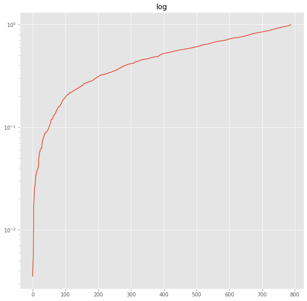

```python
# log
figure(num=None, figsize=(10, 10))
plt.plot(x, y)
plt.yscale('log')
plt.title('log')
plt.grid(True)
plt.show()
```

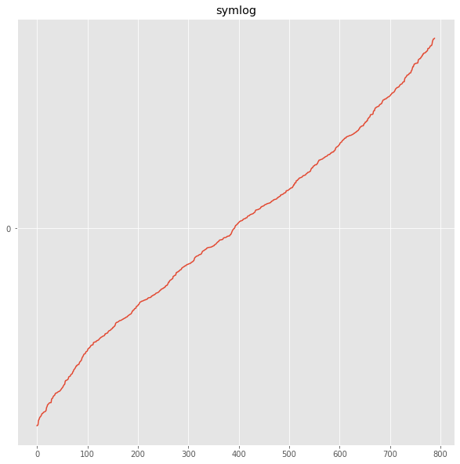

```python
# symmetric log
figure(num=None, figsize=(10, 10))

plt.plot(x, y - y.mean())
plt.yscale('symlog', linthresh=0.01)
plt.title('symlog')
plt.grid(True)
plt.show()
```

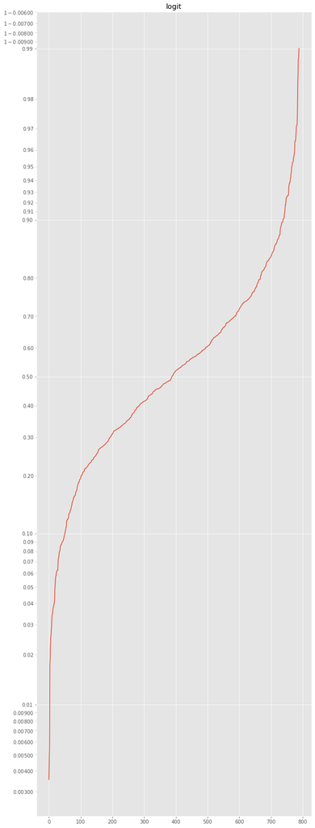

```python
# logit
figure(num=None, figsize=(10, 30))
plt.plot(x, y)
plt.yscale('logit')
plt.title('logit')
plt.grid(True)
plt.show()
```

# Matplotlib Bars

With Pyplot, you can use the bar() function to draw bar graphs The bar() function takes arguments that describes the layout of the bars. The categories and their values represented by the first and second argument as arrays.

[output not shown]

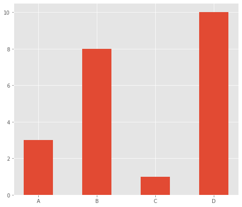

```python
x = np.array(["A", "B", "C", "D"])
y = np.array([3, 8, 1, 10])

plt.bar(x, y, width = 0.5)
plt.show()
```

# Matplotlib Pie Charts

A Pie Chart can only display one series of data. Pie charts show the size of items (called wedge) in one data series, proportional to the sum of the items. The data points in a pie chart are shown as a percentage of the whole pie. Explode: Maybe you want one of the wedges to stand out? The explode parameter allows you to do that. The explode parameter, if specified, and not None, must be an array with one value for each wedge.

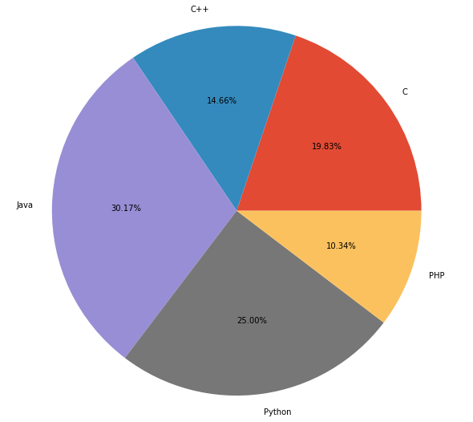

```python
fig = plt.figure()
ax = fig.add_axes([0,0,1,1])
ax.axis('equal')
langs = ['C', 'C++', 'Java', 'Python', 'PHP']
students = [23,17,35,29,12]
ax.pie(students, labels = langs,autopct='%1.2f%%')
plt.show()
```

Explode: Maybe you want one of the wedges to stand out? The explode parameter allows you to do that. The explode parameter, if specified, and not None, must be an array with one value for each wedge.

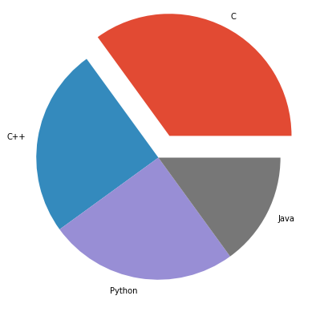

```python
y = np.array([35, 25, 25, 15])
mylabels = ["C", "C++", "Python", "Java"]
myexplode = [0.2, 0, 0, 0]
plt.pie(y, explode = myexplode , labels = mylabels)
plt.show()
```

# 3D Surface plot

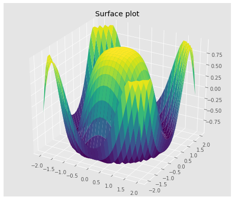

```python
from mpl_toolkits import mplot3d

x = np.outer(np.linspace(-2, 2, 30), np.ones(30))
y = x.copy().T
z = np.cos(x ** 2 + y ** 2)

fig = plt.figure()
ax = plt.axes(projection='3d')

ax.plot_surface(x, y, z,cmap='viridis', edgecolor='none')
ax.set_title('Surface plot')
plt.show()
```

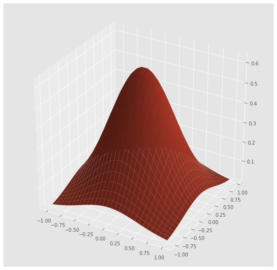

```python
from mpl_toolkits.mplot3d import Axes3D
from scipy.stats import multivariate_normal

x, y = np.mgrid[-1.0:1.0:30j, -1.0:1.0:30j]

xy = np.column_stack([x.flat, y.flat])

mu = np.array([0.0, 0.0])

sigma = np.array([.5, .5])
covariance = np.diag(sigma**2)

z = multivariate_normal.pdf(xy, mean=mu, cov=covariance)

z = z.reshape(x.shape)

fig = plt.figure(num=None, figsize=(10, 10))

ax = fig.add_subplot(111, projection='3d')



ax.plot_surface(x,y,z)

plt.show()
```

# Seaborn

Seaborn is a Python data visualization library based on matplotlib. It provides a high-level interface for drawing attractive and informative statistical graphics.

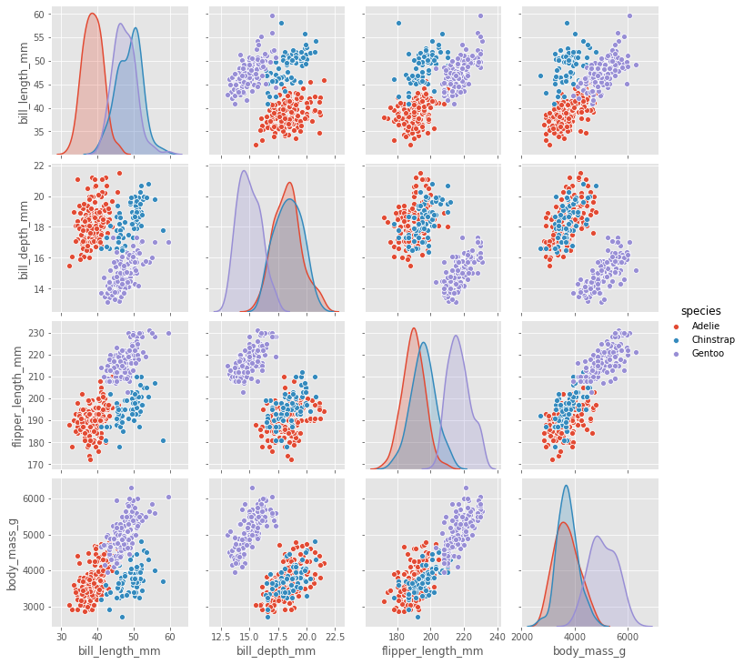

```python
import seaborn as sns
df = sns.load_dataset("penguins")
sns.pairplot(df, hue="species")
```

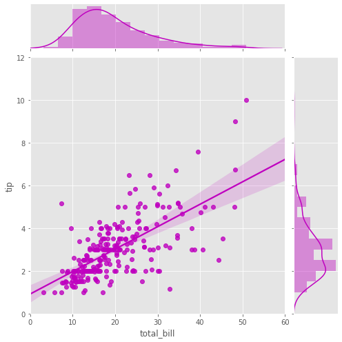

```python
tips = sns.load_dataset("tips")
g = sns.jointplot(x="total_bill", y="tip", data=tips,
                  kind="reg", truncate=False,
                  xlim=(0, 60), ylim=(0, 12),
                  color="m", height=7)
```

# Working with Images

The image module in Matplotlib package provides functionalities required for loading, rescaling and displaying image. Loading image data is supported by the Pillow library and Matplotlib relies on the Pillow library to load image data. The imread() function is used to read image data in an ndarray object of float32 dtype.

[figure not shown]

```python
import matplotlib.image as mpimg
img = mpimg.imread('mpl.png')
figure(num=None, figsize=(10, 10))
imgplot = plt.imshow(img)
```

[figure not shown]

```python
plt.imsave("logo.png", img, cmap = 'gray', origin = 'lower')
newimg = mpimg.imread('logo.png')
imgplot = plt.imshow(newimg)
```

# Get image size (width, height, dimension)

```python
img_lena = mpimg.imread('lena.png')

print(img_lena.shape)
```

```
(512, 512, 3)
```

[figure not shown]

```python
figure(num=None, figsize=(15, 10))

plt.subplot(2, 2, 1)
plt.imshow(img_lena[:,:,:])
plt.title("Orginal image")


plt.subplot(2, 2, 2)
red_img_lena = img_lena[:,:,0]
plt.imshow(red_img_lena)
plt.title("Red Chanel")



plt.subplot(2, 2, 3)
green_img_lena = img_lena[:,:,1]
plt.imshow(green_img_lena)
plt.title("Green Chanel")

plt.subplot(2, 2, 4)
blue_img_lena = img_lena[:,:,2]
plt.imshow(blue_img_lena)
plt.title("Blue Chanel")


plt.suptitle(" images")
plt.show()
```